### Statistical Modelling Course Project

Emma Yu, Dec 2014

#### Introduction

The goal of this study is to (1) determine factors related to 12 month weight loss. (2) determine whether an intervention was effective in increasing weight loss.

#### Exploritory Analysis

First, let’s briefly look at the weight loss data

```r
wt = read.table('project-dataset2.txt', header=T)
summary(wt)
```

```
##       wtch           treatment         age             race
##  Min.   :-31.847   Min.   :1.00   Min.   :50.00   Min.   :1.000
##  1st Qu.:-15.767   1st Qu.:1.00   1st Qu.:54.00   1st Qu.:3.000
##  Median :-10.443   Median :2.00   Median :59.00   Median :3.000
##  Mean   : -9.894   Mean   :1.97   Mean   :59.22   Mean   :2.632
##  3rd Qu.: -3.804   3rd Qu.:3.00   3rd Qu.:63.00   3rd Qu.:3.000
##  Max.   :  6.391   Max.   :3.00   Max.   :75.00   Max.   :4.000
##    biomarker
##  Min.   :22.67
##  1st Qu.:30.10
##  Median :32.55
##  Mean   :32.83
##  3rd Qu.:35.51
##  Max.   :45.71
```

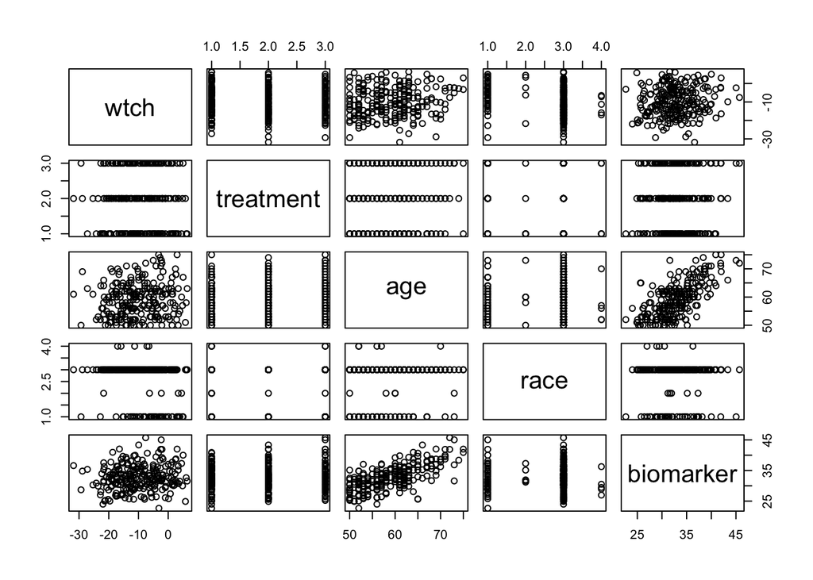

We summarize the data by race to check how many samples we have for each race group. As seen in the scatter plots, race 2 and 4 only contain 5 samples each, therefore it would be really hard to draw conclusion specifically to race 2 and 4. Race 1 has 43 samples, while race 3 contains 181. Judging from the quantiles, race 1 has systematically smaller weightloss compared to race 3. However, we should model the data in more detail, since the difference can be contributed by different age, treatment, or biomarker distributions in the race groups.

```r
table(wt$race)
```

```
##
##   1   2   3   4
##  43   5 181   5
```

```r
by(wt$wtch, wt$race, summary)
```

```
## wt$race: 1
##    Min. 1st Qu.  Median    Mean 3rd Qu.    Max.
## -29.320 -10.950  -5.426  -6.186  -1.324   5.023
## --------------------------------------------------------
## wt$race: 2
##    Min. 1st Qu.  Median    Mean 3rd Qu.    Max.
## -21.720  -6.283  -2.297  -4.482   3.376   4.511
## --------------------------------------------------------
## wt$race: 3
##    Min. 1st Qu.  Median    Mean 3rd Qu.    Max.
## -31.850 -16.580 -11.740 -10.880  -4.686   6.391
## --------------------------------------------------------
## wt$race: 4
##    Min. 1st Qu.  Median    Mean 3rd Qu.    Max.
## -17.020 -15.860 -11.290 -11.560  -7.127  -6.488
```

[output not shown]

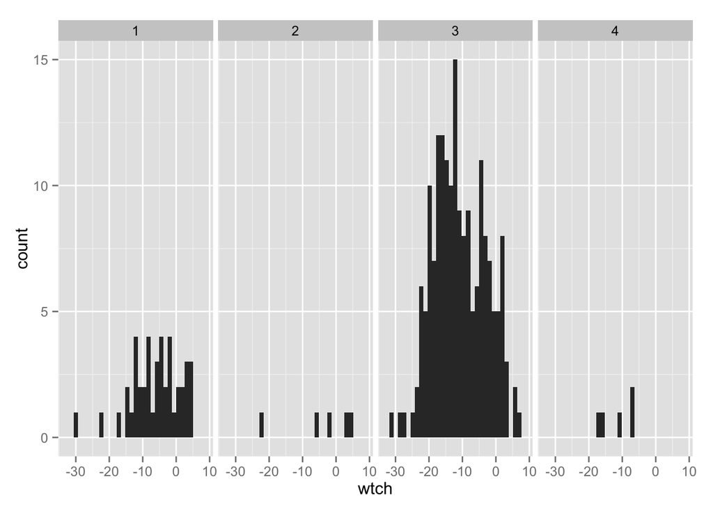

```r
# Let's summary the weight loss by race.
# Do a box plot or something?
library(ggplot2)
qplot(x=wtch, data = wt) +
  facet_wrap(~race, ncol =4)
```

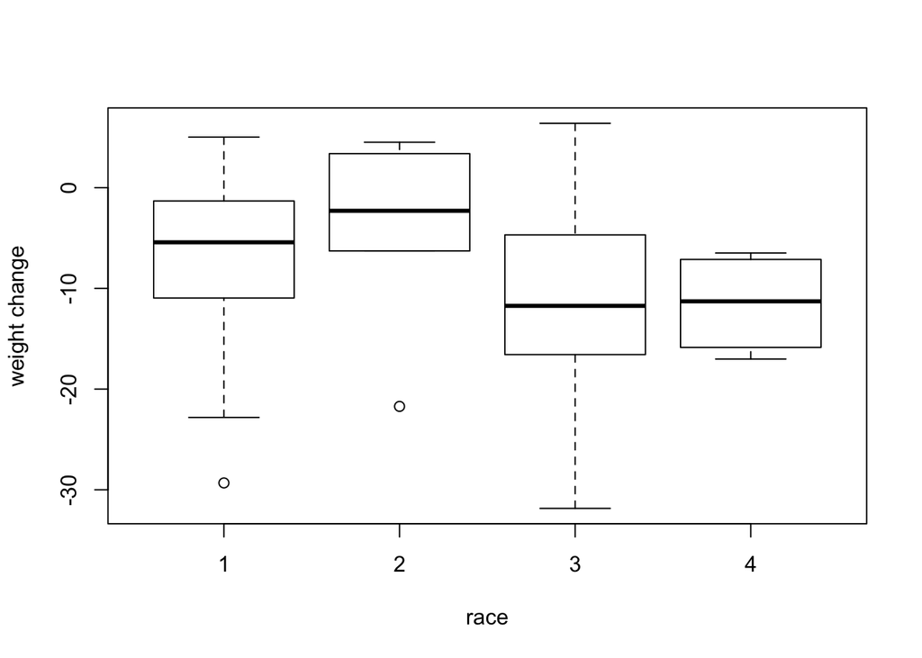

```r
boxplot(wt$wtch~wt$race,ylab='weight change',xlab="race")
```

```r
# there are two outliers, maybe simply not representative?
```

#### Frequentist Analysis

First, let’s contruct a full model with all data points and all avaliable variables as covariants.

```r
fitall <- lm(wtch ~ as.factor(treatment) + age + as.factor(race) + biomarker, data =wt)
summary(fitall)
```

```
##
## Call:
## lm(formula = wtch ~ as.factor(treatment) + age + as.factor(race) +
##     biomarker, data = wt)
##
## Residuals:
##      Min       1Q   Median       3Q      Max
## -21.3252  -5.3880  -0.2753   5.7136  19.2159
##
## Coefficients:
##                        Estimate Std. Error t value Pr(>|t|)
## (Intercept)           -18.29184    4.99303  -3.663  0.00031 ***
## as.factor(treatment)2  -1.12395    1.21312  -0.926  0.35518
## as.factor(treatment)3  -1.79467    1.27184  -1.411  0.15960
## age                     0.17942    0.11277   1.591  0.11300
## as.factor(race)2        0.47591    3.63383   0.131  0.89592
## as.factor(race)3       -5.46219    1.33050  -4.105 5.64e-05 ***
## as.factor(race)4       -5.67994    3.63573  -1.562  0.11963
## biomarker               0.09319    0.16448   0.567  0.57158
## ---
## Signif. codes:  0 '***' 0.001 '**' 0.01 '*' 0.05 '.' 0.1 ' ' 1
##
## Residual standard error: 7.614 on 226 degrees of freedom
## Multiple R-squared:  0.09939,    Adjusted R-squared:  0.07149
## F-statistic: 3.563 on 7 and 226 DF,  p-value: 0.001179
```

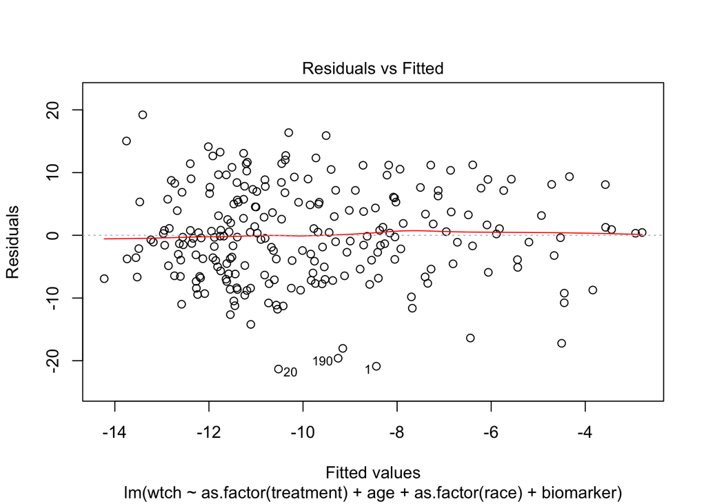

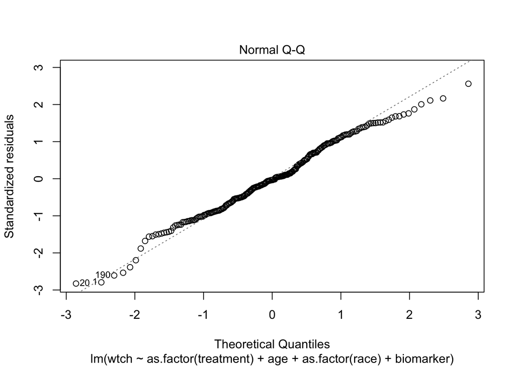

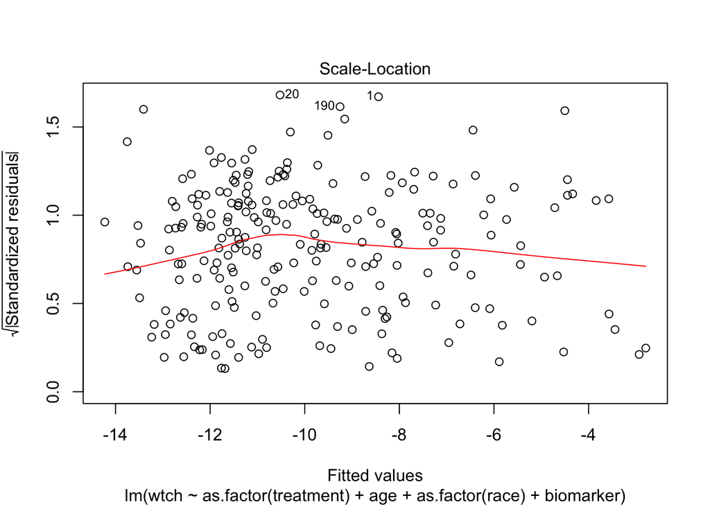

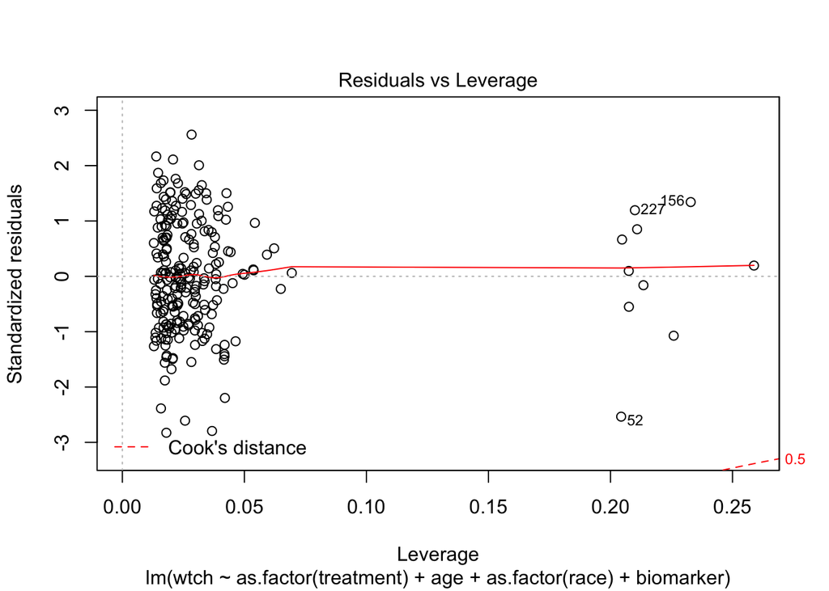

```r
plot(fitall)
```

```r
# Let's define dummy variables to allow different slopes for different races
wt$r1 <- 0
wt$r2 <- 0
wt$r3 <- 0
wt$r1[wt$race ==1] <-1
wt$r2[wt$race ==2] <-1
wt$r3[wt$race ==3] <-1


fit <- lm(wtch ~ age + r1 + r2 + r3 + r1*age + r2*age + r3*age + biomarker + as.factor(treatment), wt)
summary(fit)
```

```
##
## Call:
## lm(formula = wtch ~ age + r1 + r2 + r3 + r1 * age + r2 * age +
##     r3 * age + biomarker + as.factor(treatment), data = wt)
##
## Residuals:
##      Min       1Q   Median       3Q      Max
## -21.2898  -5.3825  -0.2422   5.4736  19.2421
##
## Coefficients:
##                        Estimate Std. Error t value Pr(>|t|)
## (Intercept)            -1.55479   30.05417  -0.052    0.959
## age                    -0.20399    0.52692  -0.387    0.699
## r1                    -18.86944   32.31518  -0.584    0.560
## r2                     -6.72321   41.50758  -0.162    0.871
## r3                    -22.78076   30.60644  -0.744    0.457
## biomarker               0.07768    0.17082   0.455    0.650
## as.factor(treatment)2  -1.06201    1.22427  -0.867    0.387
## as.factor(treatment)3  -1.63710    1.29465  -1.265    0.207
## age:r1                  0.42746    0.55898   0.765    0.445
## age:r2                  0.23286    0.70153   0.332    0.740
## age:r3                  0.40066    0.52890   0.758    0.450
##
## Residual standard error: 7.653 on 223 degrees of freedom
## Multiple R-squared:  0.1022, Adjusted R-squared:  0.06197
## F-statistic: 2.539 on 10 and 223 DF,  p-value: 0.006436
```

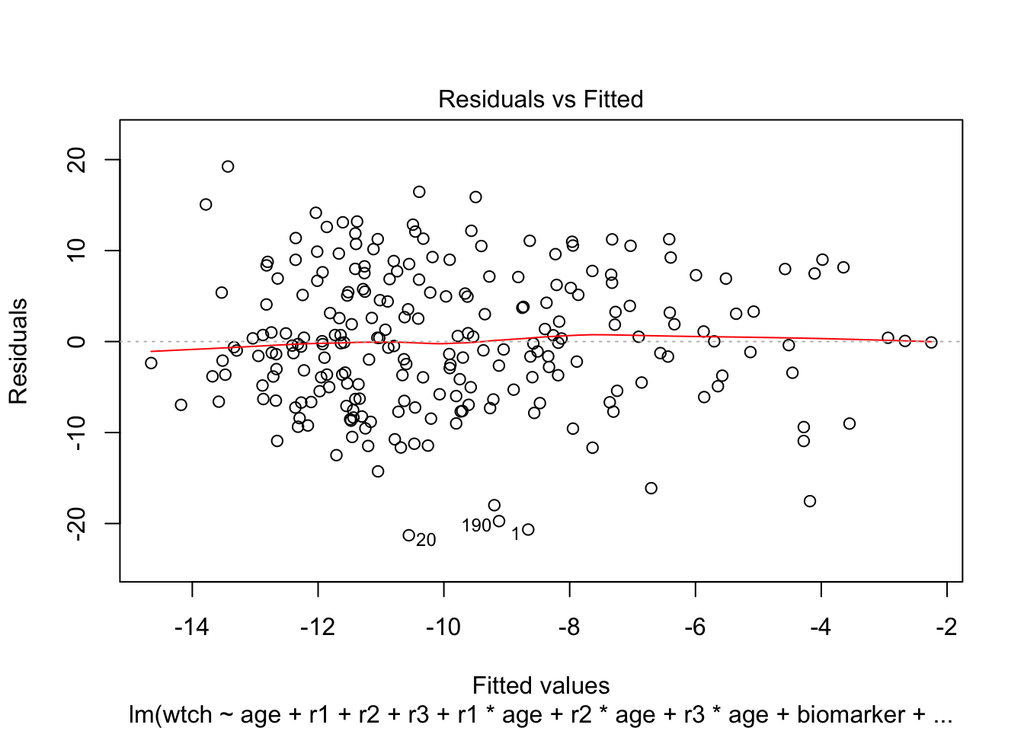

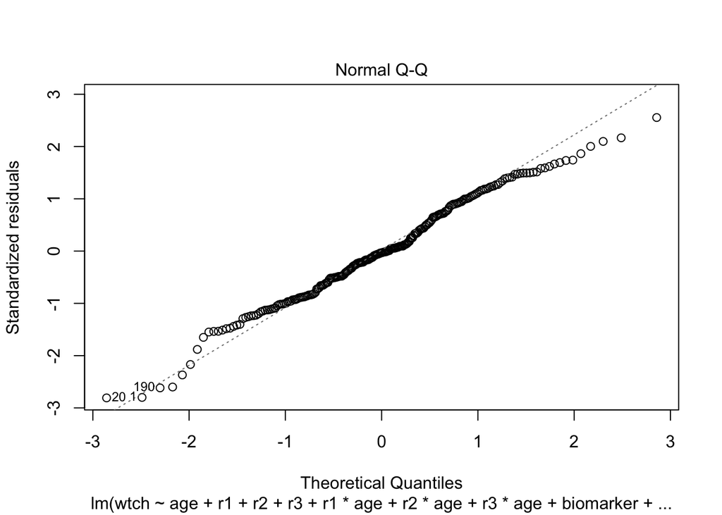

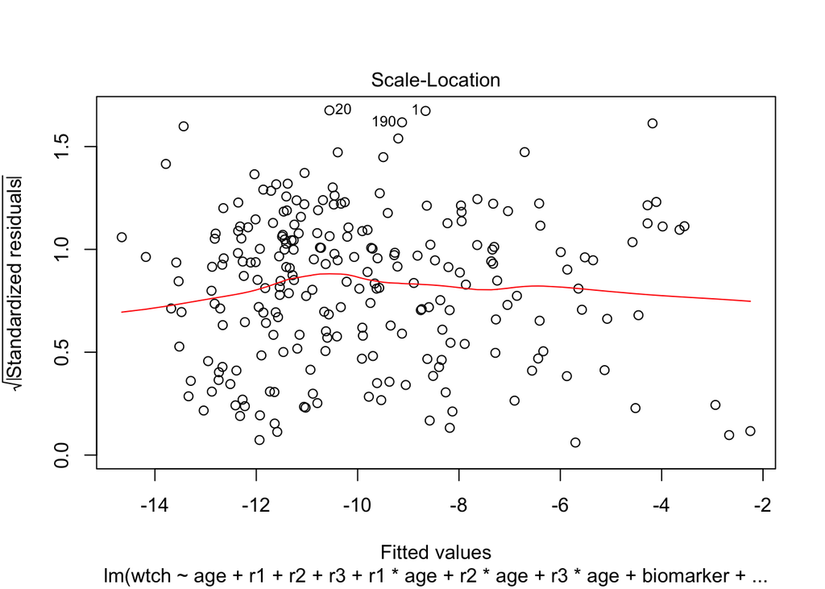

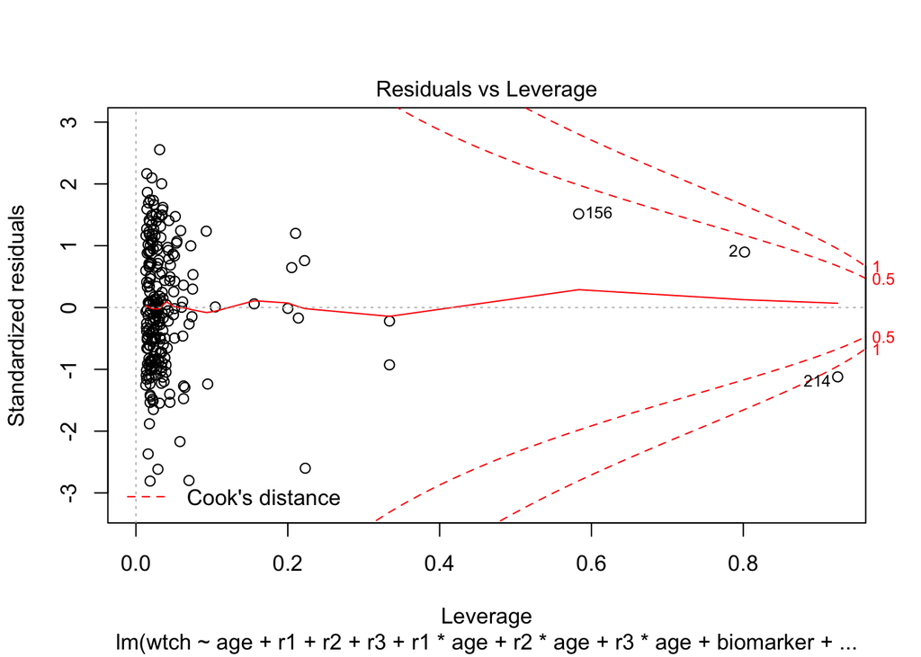

```r
plot(fit)
```

```r
str(wt)
```

```
## 'data.frame':    234 obs. of  8 variables:
##  $ wtch     : num  -29.32 -2.3 2.84 -12.21 -11.12 ...
##  $ treatment: int  3 3 1 2 2 2 2 1 2 3 ...
##  $ age      : int  50 73 52 56 71 61 70 65 50 52 ...
##  $ race     : int  1 2 1 3 3 1 3 3 3 3 ...
##  $ biomarker: num  28.7 31.6 31 31.6 40 ...
##  $ r1       : num  1 0 1 0 0 1 0 0 0 0 ...
##  $ r2       : num  0 1 0 0 0 0 0 0 0 0 ...
##  $ r3       : num  0 0 0 1 1 0 1 1 1 1 ...
```

```r
wt$t1 <- 0
wt$t2 <- 0
wt$t1[wt$treatment ==2] <-1
wt$t2[wt$treatment ==3] <-1
fit <- lm(wtch ~ age + r1 + r2 + r3 + r1*age + r2*age + r3*age + t1 + t2 + biomarker, wt)
summary(fit)
```

```
##
## Call:
## lm(formula = wtch ~ age + r1 + r2 + r3 + r1 * age + r2 * age +
##     r3 * age + t1 + t2 + biomarker, data = wt)
##
## Residuals:
##      Min       1Q   Median       3Q      Max
## -21.2898  -5.3825  -0.2422   5.4736  19.2421
##
## Coefficients:
##              Estimate Std. Error t value Pr(>|t|)
## (Intercept)  -1.55479   30.05417  -0.052    0.959
## age          -0.20399    0.52692  -0.387    0.699
## r1          -18.86944   32.31518  -0.584    0.560
## r2           -6.72321   41.50758  -0.162    0.871
## r3          -22.78076   30.60644  -0.744    0.457
## t1           -1.06201    1.22427  -0.867    0.387
## t2           -1.63710    1.29465  -1.265    0.207
## biomarker     0.07768    0.17082   0.455    0.650
## age:r1        0.42746    0.55898   0.765    0.445
## age:r2        0.23286    0.70153   0.332    0.740
## age:r3        0.40066    0.52890   0.758    0.450
##
## Residual standard error: 7.653 on 223 degrees of freedom
## Multiple R-squared:  0.1022, Adjusted R-squared:  0.06197
## F-statistic: 2.539 on 10 and 223 DF,  p-value: 0.006436
```

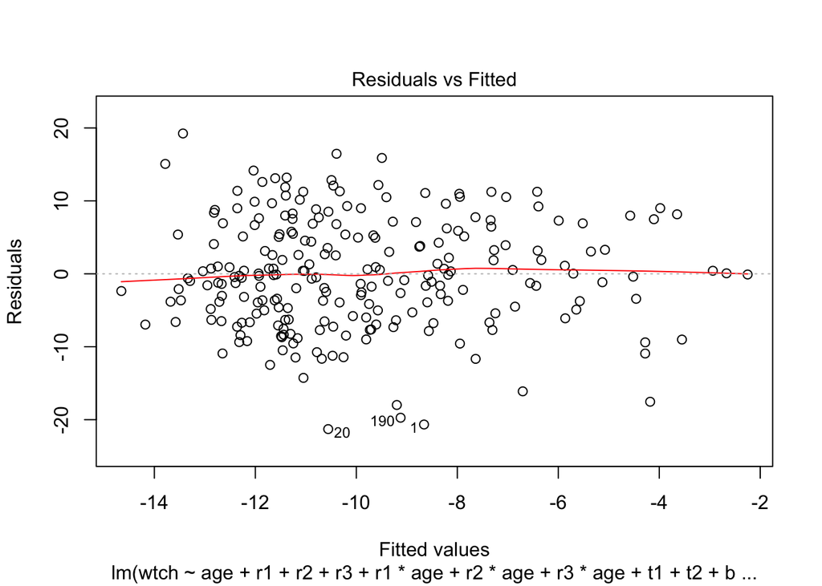

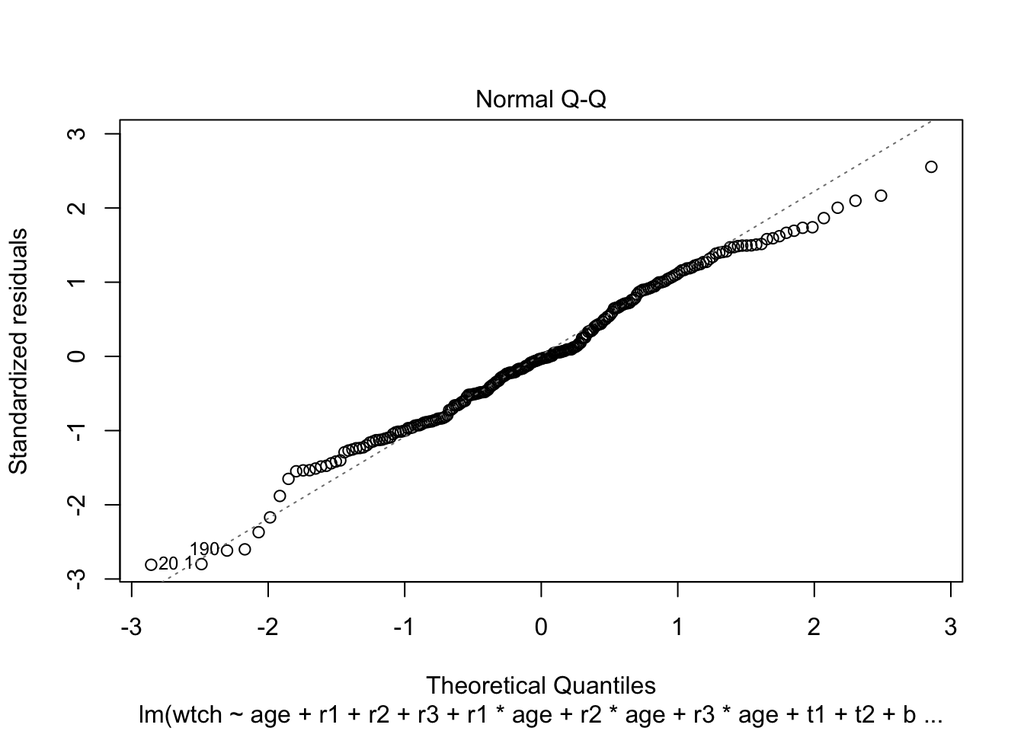

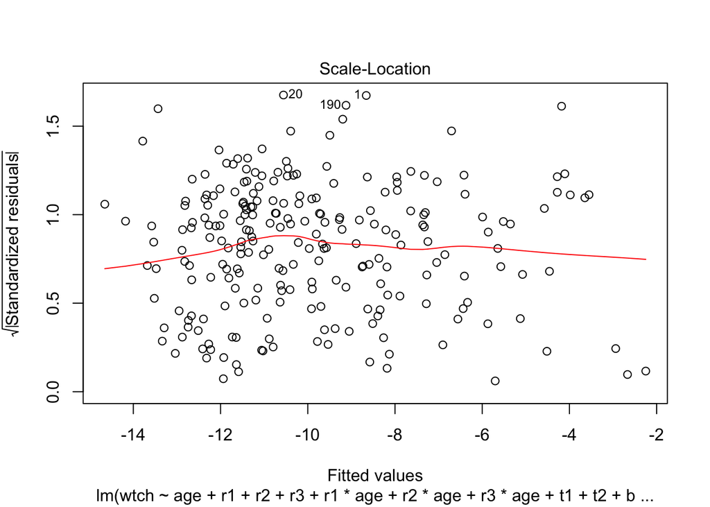

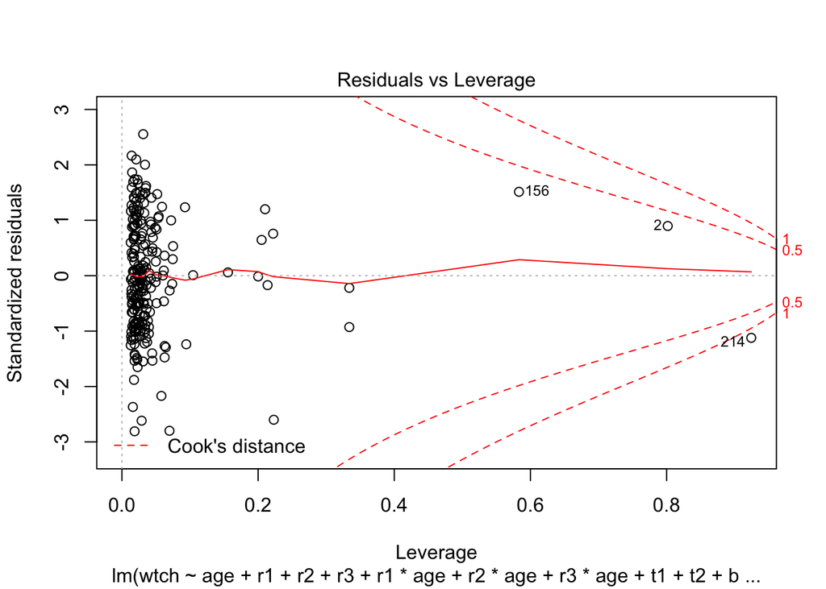

```r
plot(fit)
```

```r
# so the treatment seems to be more significant than race.
```

We don’t see any strucutre in the residual vs. fittet plot. We can see 10 points with very large leverage, they can potentially lead to a poor model fit. (Are the outliers? Do we need to remove them?)

Include different slopes for the race? Do a anova test

#### Bayesian Approach

What kind of diagnostic can I do?

```r
# construct dummy variables for the factor variable.
N <-dim(wt)[1]
wt$r1 <- 0
wt$r2 <- 0
wt$r3 <- 0
wt$r1[wt$race ==1] <-1
wt$r2[wt$race ==2] <-1
wt$r3[wt$race ==3] <-1

wt$t1 <- 0
wt$t2 <- 0
wt$t1[wt$treatment ==2] <-1
wt$t2[wt$treatment ==3] <-1

wtdata = list('wtch'=wt$wtch, 'dum11' = wt$r1, 'dum12' = wt$r2, 'dum13' = wt$r3, 'age'=wt$age, 'bio'=wt$biomarker, 'dum21' = wt$t1, 'dum22' = wt$t2, 'N'=N)

library(rjags)
jagsmodel <- jags.model('wt_model.txt',
                        data = wtdata,
                        list(list('beta'=c(0,0,0,0,0,0,0,0)), list('beta'=c(1,1,1,1,1,1,1,1))),
                        n.chains = 2)
```

```
##    Graph Size: 2388
##
```

```r
jagsfit <- jags.samples(jagsmodel, "beta", n.iter=10000)
summary(jagsfit$beta, quantile, prob=c(0.025, 0.5, 0.975))
```

```
## mcarray:
##            [,1]      [,2]      [,3]        [,4]        [,5]       [,6]
## 2.5%  -34.46439 -1.715759 -3.550389 -6.88974104 -0.05277245 -0.2518708
## 50%   -22.90572  5.283353  5.752968 -0.08978165  0.16063738  0.1083073
## 97.5% -10.63172 12.487368 15.088591  6.81452093  0.40629766  0.3994236
##            [,7]       [,8]
## 2.5%  -3.508585 -4.2758495
## 50%   -1.105618 -1.7668985
## 97.5%  1.317008  0.7914285
##
## Marginalizing over: iteration(10000),chain(2)
```

```r
# onlye par 1 seems to be within 97.5% confident non-zero.
# Let's write down the mean and the sig and see how likely the coefficient is non-zero
```

```r
#Yrep = matrix((0, 200, 1000))
#for(i in 1:200){
#  for(j in 1:800){
#    Yrep[i,j]=rnorm(1, mean = as.matrix(t(X[i,])) %*% beta[j,], sd = sqrt(1/tau[j]))
#  }
#}
```

Should I build a few different models and compare the DIC, LPML or something? Or combine the intervention Check the mixing of two variables for the two chain. check it in a bit more detail, see if we need to thin it, define burn in or anything. At least mention if in the write up.

Do CPO, talk about DIC a bit. Draw samples from the predicted distribution, test the number of outliers and stuff (see HW5 for an example.)

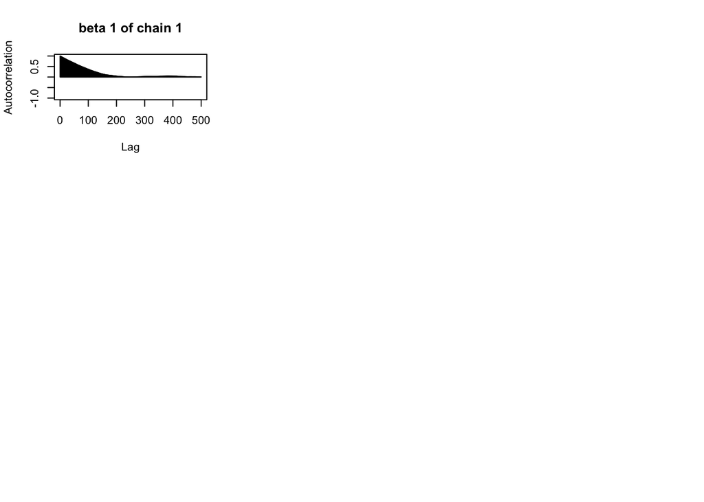

```r
# the mixing looks terrible, let's thin the chain by 300?
par(mfrow=c(2, 4))
autocorr.plot(jagsfit$beta[1, ,1], lag.max=500, main='beta 1 of chain 1')
```

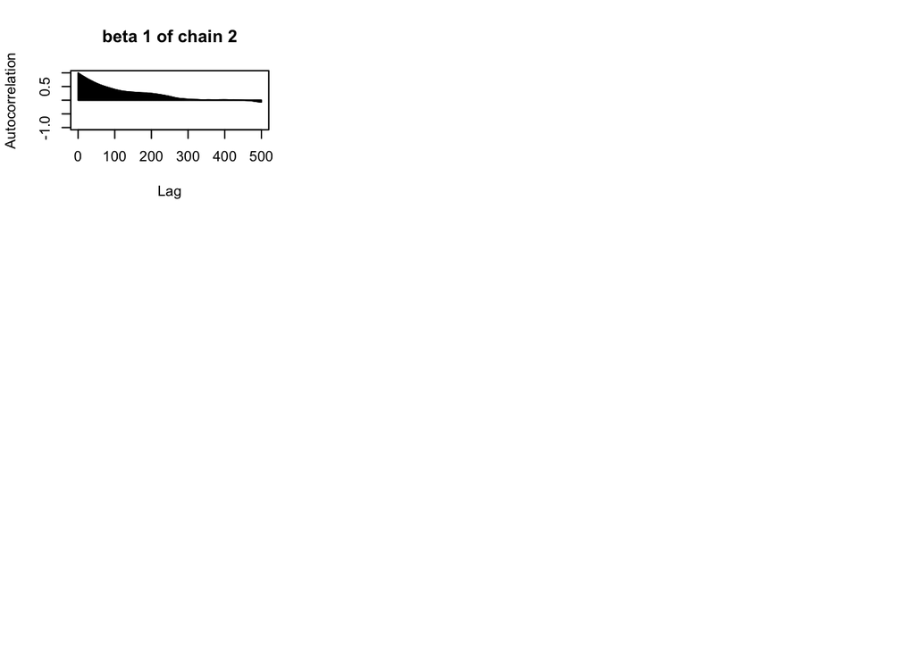

```r
autocorr.plot(jagsfit$beta[1, ,2], lag.max=500, main='beta 1 of chain 2')
```

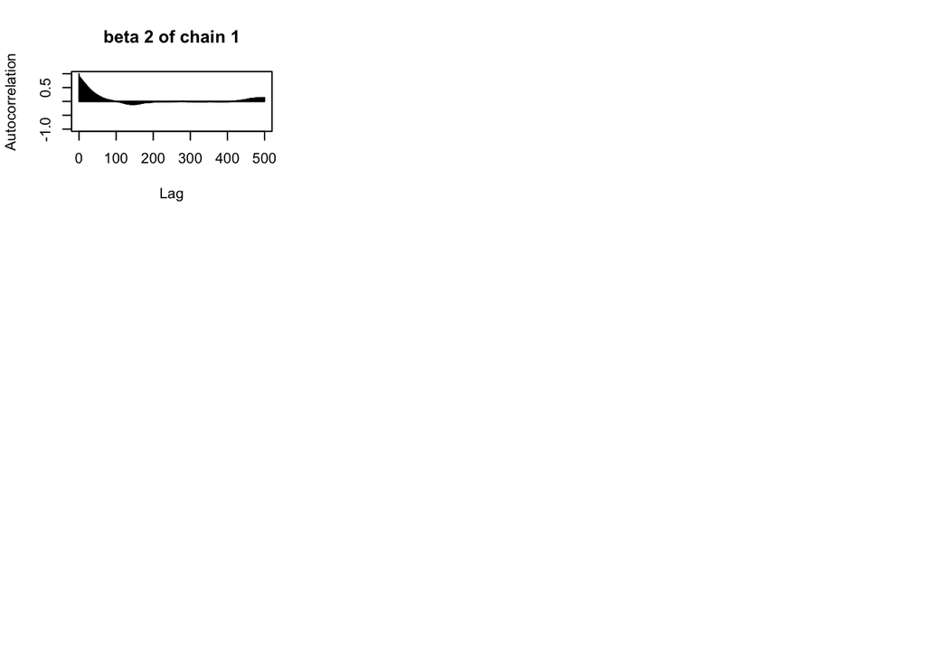

```r
autocorr.plot(jagsfit$beta[2, ,1], lag.max=500, main='beta 2 of chain 1')
```

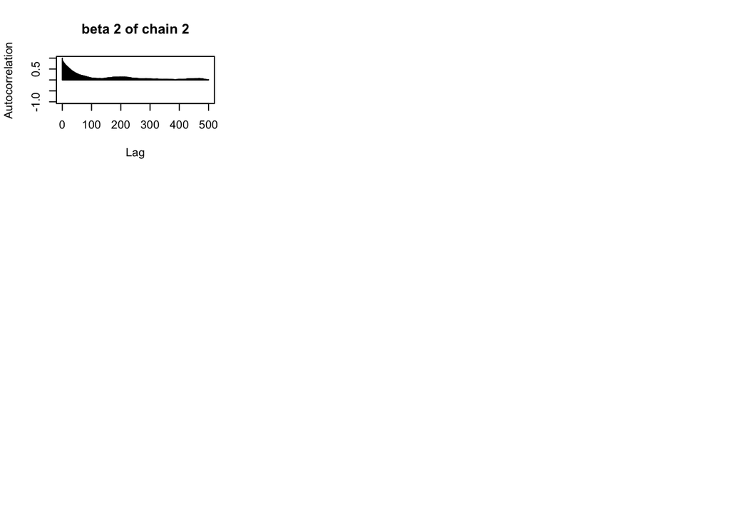

```r
autocorr.plot(jagsfit$beta[2, ,2], lag.max=500, main='beta 2 of chain 2')
```

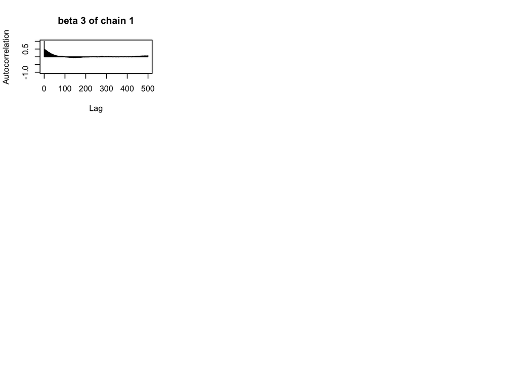

```r
autocorr.plot(jagsfit$beta[3, ,1], lag.max=500, main='beta 3 of chain 1')
```

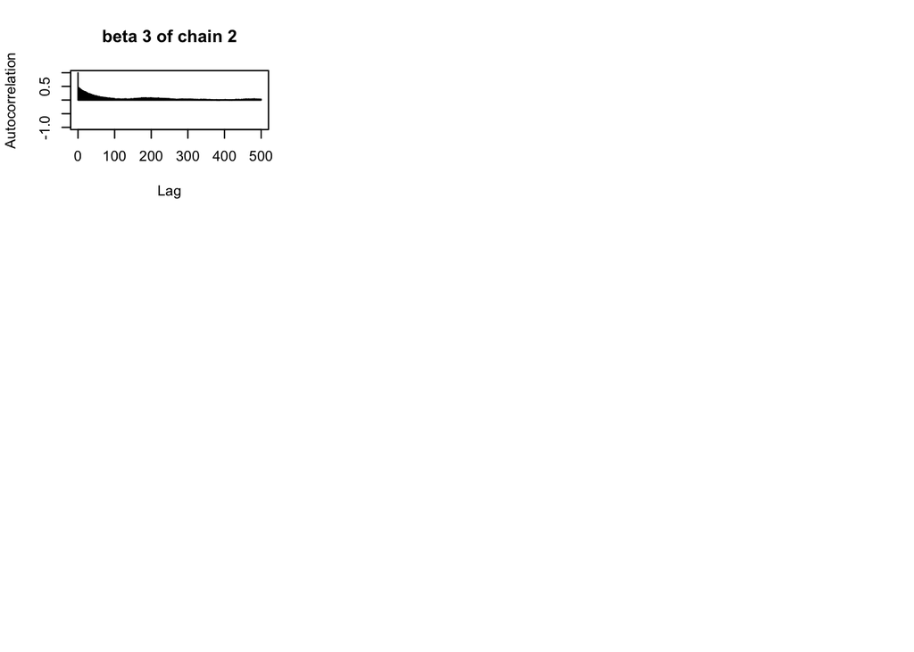

```r
autocorr.plot(jagsfit$beta[3, ,2], lag.max=500, main='beta 3 of chain 2')
```

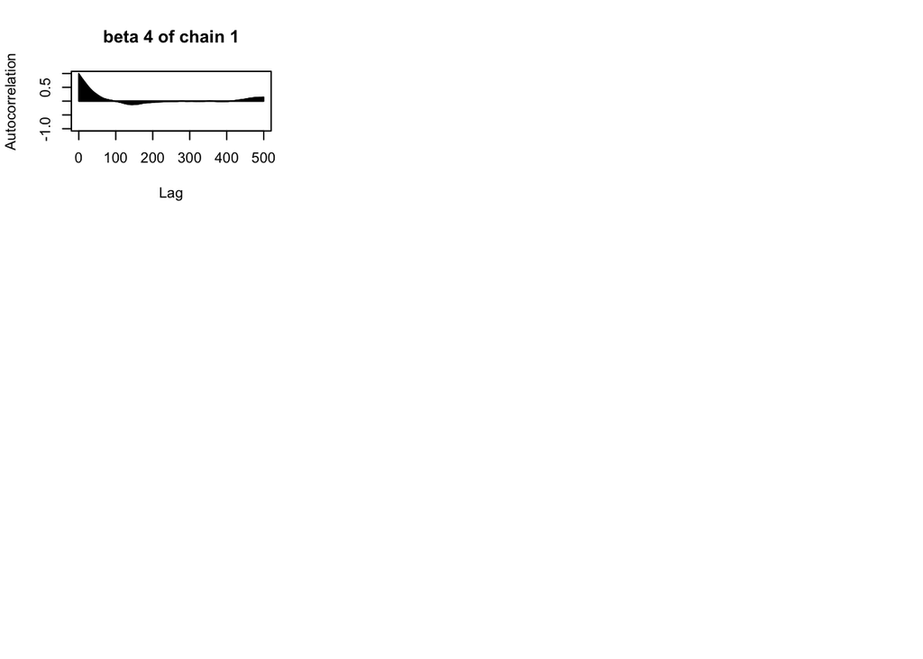

```r
autocorr.plot(jagsfit$beta[4, ,1], lag.max=500, main='beta 4 of chain 1')
```

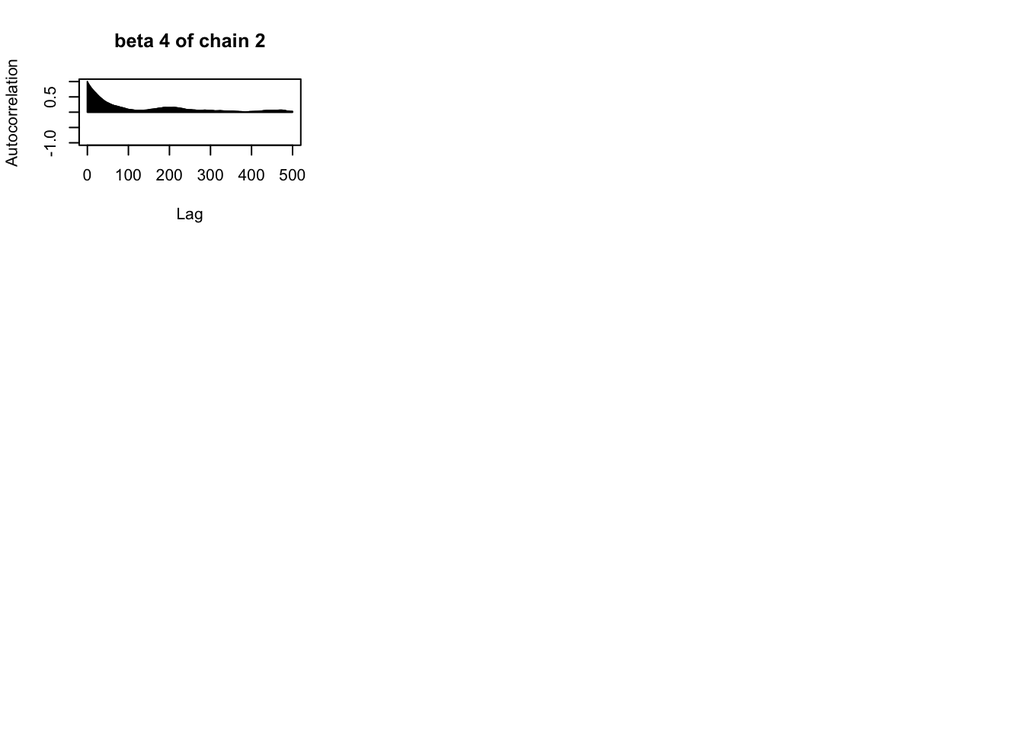

```r
autocorr.plot(jagsfit$beta[4, ,2], lag.max=500, main='beta 4 of chain 2')
```

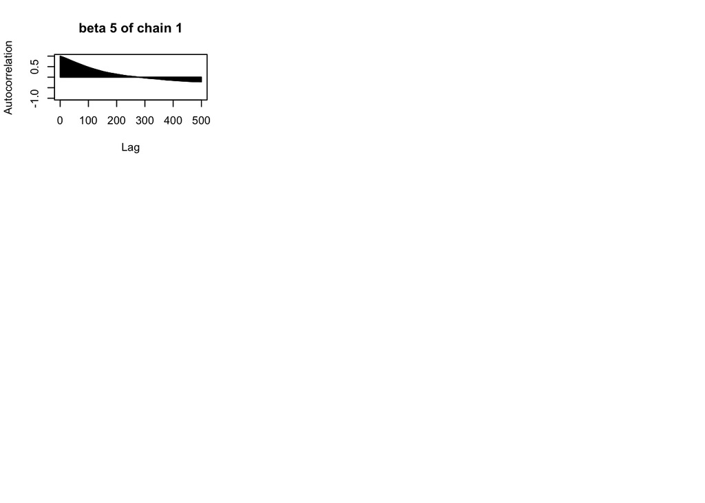

```r
autocorr.plot(jagsfit$beta[5, ,1], lag.max=500, main='beta 5 of chain 1')
```

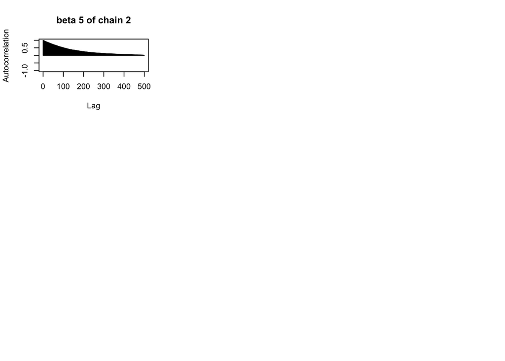

```r
autocorr.plot(jagsfit$beta[5, ,2], lag.max=500, main='beta 5 of chain 2')
```

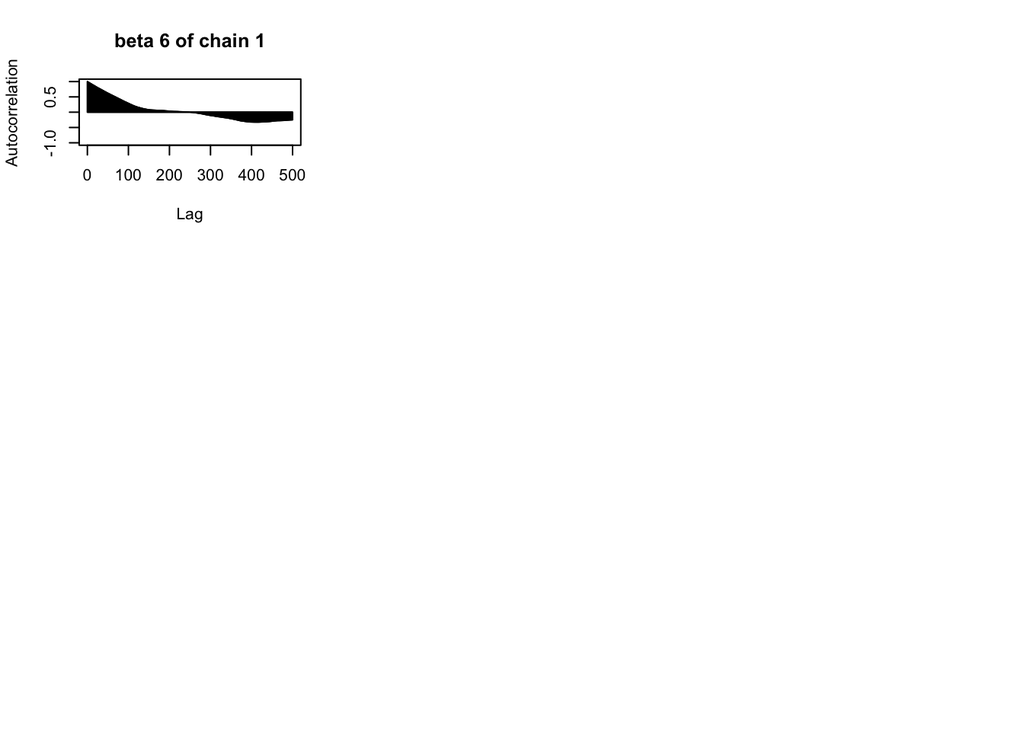

```r
autocorr.plot(jagsfit$beta[6, ,1], lag.max=500, main='beta 6 of chain 1')
```

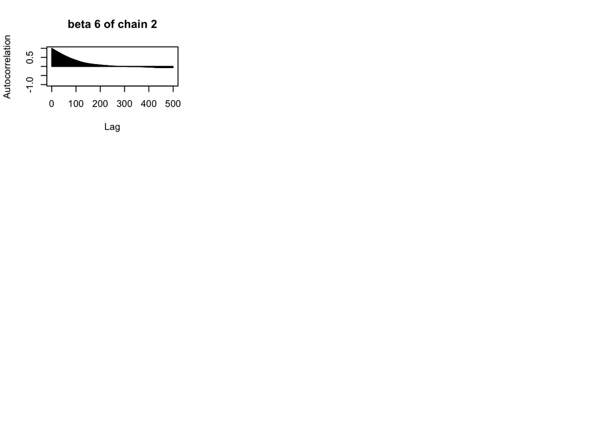

```r
autocorr.plot(jagsfit$beta[6, ,2], lag.max=500, main='beta 6 of chain 2')
```

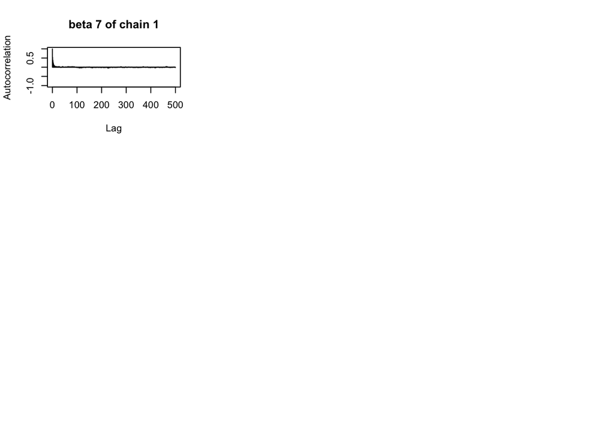

```r
autocorr.plot(jagsfit$beta[7, ,1], lag.max=500, main='beta 7 of chain 1')
```

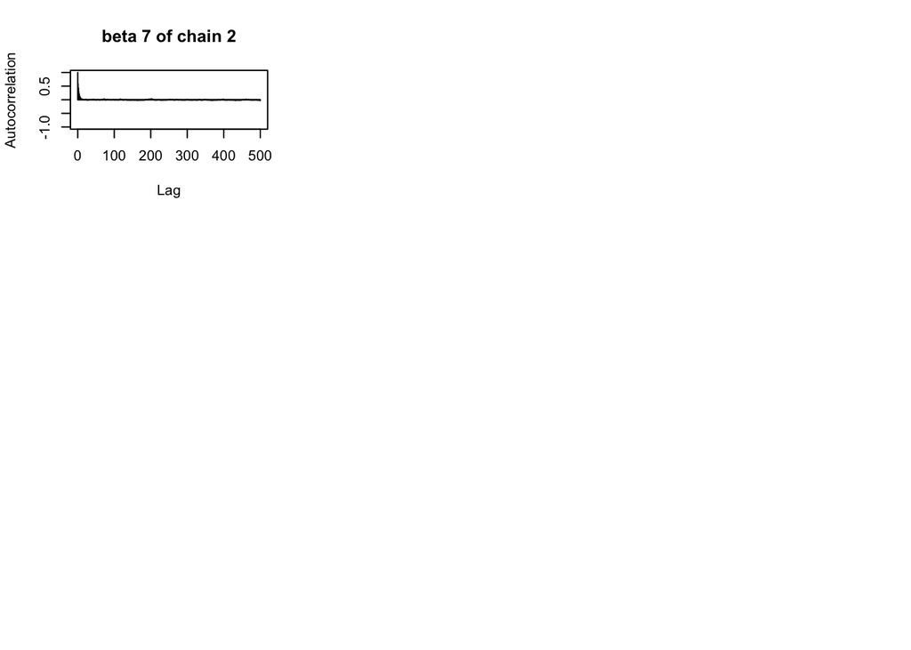

```r
autocorr.plot(jagsfit$beta[7, ,2], lag.max=500, main='beta 7 of chain 2')
```

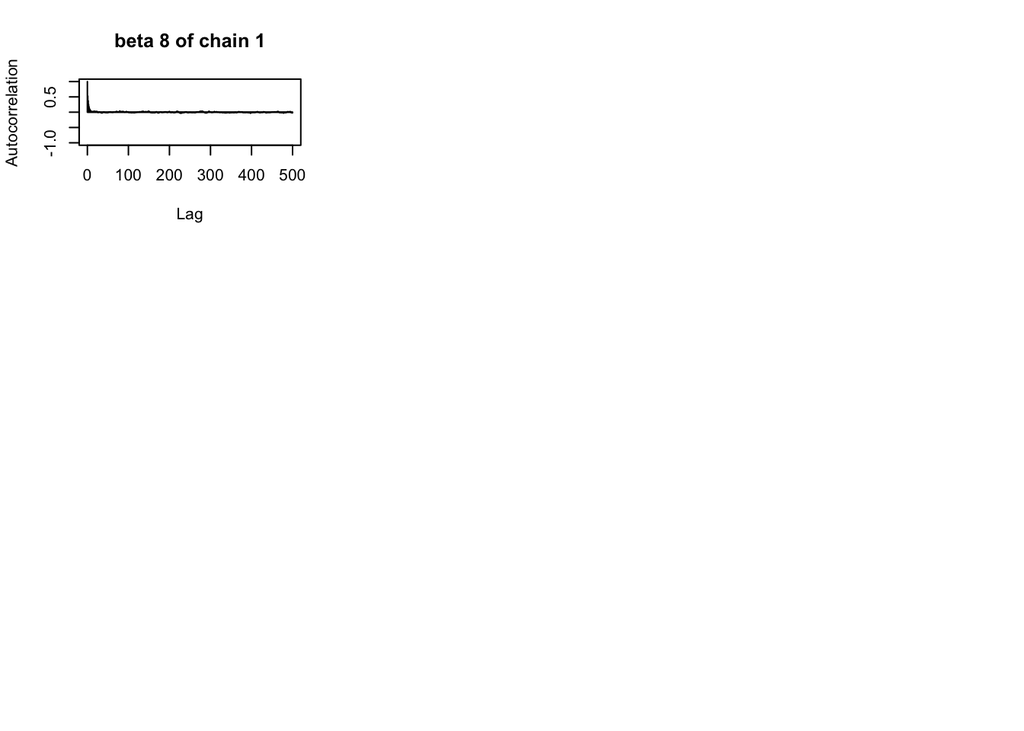

```r
autocorr.plot(jagsfit$beta[8, ,1], lag.max=500, main='beta 8 of chain 1')
```